# Acceptance and Commitment Therapy Versus Cognitive Behavioral Therapy for Insomnia: A Bayesian re-analysis

Marwin Carmo

June 10, 2024

# Introduction

This work presents a Bayesian re-analysis of the randomized controlled trial conducted by Rafihi-Ferreira et al. (in press), which compared the efficacy of Acceptance and Commitment Therapy (ACT) and Cognitive Behavioral Therapy for Insomnia (CBT-I) in treating insomnia. The original study primarily measured changes in the Insomnia Severity Index (ISI) scores at post-treatment and follow-up stages. Data were analyzed using mixed-effects models, incorporating random intercepts for participants and fixed effects for group variables. Treatment effects were evaluated based on the fixed effects of group variables (ACT vs. CBT-I and ACT vs. waitlist) and their interaction with time points (pre-test vs. post-test and pre-test vs. six-month follow-up). The original code and data can be accessed at https://osf.io/zs98u/.

The data in Rafihi-Ferreira et al. (in press) was collected through a self-administered survey managed using REDCap. Participants were adults 18 to 59 years old and meeting criteria for chronic insomnia. Participants who met the inclusion criteria (as described in Rafihi-Ferreira et al. (in press)) were randomized to the ACT-I, CBT-I or waitlist (WL) group. To ensure that the groups were well distributed in terms of insomnia severity, randomization was stratified by insomnia severity index (ISI, mild and moderate insomnia with a score between 8-21 vs severe insomnia with a score between 22-28). Treatments were provided in the context of six weekly group therapy sessions lasting 90 to 120 minutes with groups consisting of five to seven participants that took place on Zoom.Outcomes were assessed post-treatment (one week after completion of treatment) and at the six-month follow-up.

## Motivation

As a co-author of Rafihi-Ferreira et al. (in press) and having performed much of the initial analysis, I decided to re-examine the data using a Bayesian framework. This approach allows for a more comprehensive quantification of uncertainty in the model and estimates. Specifically, the p-values for the interactions in the original analysis were larger than 0.01 and close to the conventional significance threshold. By incorporating prior knowledge into the model, I aim to derive more precise estimates and draw more informed conclusions about the comparative effectiveness of the therapies.

In this work, I opted to not include the control group in the model as there is enough evidence that ACT or CBT-I are both effective for treating insomnia symptoms compared to controls (El Rafihi-Ferreira et al., 2020; Rafihi-Ferreira et al., 2023). The motivation for re-running these analyses lies in quantifying uncertainty in the estimates using prior knowledge.

# Model formulation

The ISI scores are realized from a normal distribution with mean $\mu_{ti}$ and fixed standard deviation $\sigma$. We can specify $\mu_{ti}$ as a linear mixed effects model, for $i$ = 1, 2,…,$n_t$ participants and $t$ = 1, 2, 3, assessments. The intercept is represented by $\alpha$, the fixed effects are captured by $\beta_{1}, \beta_{2}, \beta_{3}, \beta_{4}$, and $\beta_{5}$, and the random effects by $u_{0i}, u_{1i}$, and $u_{2i}$. The reference categories are ACT for $\text{treatment}$ and the baseline assessment for $\text{time}$.

$$\begin{aligned}
\text{ISI}_{i} &\sim \mathcal{N}(\mu_{ti}, \sigma)\\
\mu_{ti} &= \alpha + \beta_{1}(\text{time})_{ti}^{(1)} +
\beta_{2}(\text{time})_{ti}^{(2)} + \beta_{3}(\text{treatment})_i \\
&+ \beta_{4} (\text{treatment})_i (\text{time})_{ti}^{(1)} +
\beta_{5} (\text{treatment})_i (\text{time})_{ti}^{(2)} \\
&+ \left ( u_{0i} + u_{1i} \text{time}_{ti}^{(1)} + u_{2i}
\text{time}_{ti}^{(2)} \right).
\\
\sigma &\sim St^{+}(3,0,1)
\end{aligned}$$

$$\begin{aligned}
\alpha &\sim \mathcal{N}(0, 2)\\
\beta_1, \beta_2, ...,\beta_5 &\sim \mathcal{N}(0, 5)\\
\end{aligned}$$

The priors for the random effects are modeled from a multivariate normal prior with covariance matrix $\boldsymbol{\Sigma}$. The covariance matrix $\boldsymbol{\Sigma}$ can be decomposed into $\boldsymbol\Sigma = \boldsymbol{\tau}\boldsymbol{\Omega\tau}'$, where $\boldsymbol{\tau}$ is a diagonal matrix where the diagonal elements are the random-effect standard deviations and $\boldsymbol\Omega$ is the correlation matrix that contains the correlations among all random effects. The LKJ prior correlation matrix’ single parameter $\eta$ was set to one to place a uniform prior over all correlation matrices.

$$\begin{aligned}
\begin{bmatrix} u_{0i} \\ u_{1i} \\ u_{2i} \end{bmatrix} &\sim
\mathcal{N}
\begin{Bmatrix}
\boldsymbol{0}=
\begin{bmatrix} 0 \\ 0 \\ 0 \end{bmatrix},
\boldsymbol{\Sigma}=
\begin{bmatrix} \tau^2_{u_{0i}} \\
\tau_{u_{0i}u_{1i}} & \tau^2_{u_{1i}} \\
\tau_{u_{0i}u_{2i}} & \tau_{u_{1i}u_{2i}}
& \tau^2_{u_{2i}}
\end{bmatrix}
\end{Bmatrix}\\
\boldsymbol{\Sigma} &=
\boldsymbol{\tau}\boldsymbol{\Omega\tau}'\\
\boldsymbol\Omega &\sim \text{LKJ}(\eta = 1)\\
\tau^2_{u_{0i}}, \tau^2_{u_{1i}}, \tau^2_{u_{2i}} &\sim
\Gamma(1,0.5)
\end{aligned}$$

# Load packages and data

```r
library(ggplot2)
library(dplyr)
library(brms)
library(ggmcmc)
library(patchwork)
```

```r
data <- read.csv("../data/clean_data.csv") |>
  # transform grouping variable to factor
  #dplyr::mutate(randomizacao = factor(randomizacao)) |>
  # select only the relevant variables
  # randomizacao = randomization group, igi_escore = sum score on insomnia severity index
  dplyr::select(
    record_id, redcap_event_name, randomizacao, igi_escore
  ) |>
  # filter out the baseline measure applied only to controls
  dplyr::filter(redcap_event_name %in% c(
    "elegibilidade_arm_1",
    "desfechos_arm_1", "followup_arm_1"),
    # also exclude controls since we're only interested in ACT vs. CBT
    randomizacao != 3
    ) |>
  # code events (baseline, post, and follow-up) as numeric
  dplyr::mutate(
    redcap_event_name = dplyr::case_when(
      redcap_event_name == "elegibilidade_arm_1" ~ 0,
      redcap_event_name == "desfechos_arm_1" ~ 1,
      redcap_event_name == "followup_arm_1" ~ 2
    ),
    #  give "real" names to randomization groups
    randomizacao = dplyr::case_when(
      randomizacao == 1 ~ "ACT",
      randomizacao == 2 ~ "CBT"),
    # scale the outcome (insomnia score)
    igi_escore = c(scale(igi_escore, center = TRUE, scale = TRUE))
    )

head(data)
```

|  | record_id | redcap_event_name | randomizacao | igi_escore |
| --- | --- | --- | --- | --- |
| 1 | 3 | 0 | ACT | 1.1502574 |
| 2 | 3 | 1 | ACT | -0.5303605 |
| 3 | 3 | 2 | ACT | -0.2247936 |
| 4 | 16 | 0 | CBT | 0.6919070 |
| 5 | 16 | 1 | CBT | -1.1414942 |
| 6 | 16 | 2 | CBT | -1.2942777 |

# Building the model

## Check for missing data

First, lets check how many responses we have at each time point in each group.

```r
data |>
  dplyr::with_groups(c(redcap_event_name, randomizacao),
                     summarise,
                     n = n(),
                     pct_missing = sum(is.na(igi_escore))/n())
```

| redcap_event_name | randomizacao | n | pct_missing |
| --- | --- | --- | --- |
| 0 | ACT | 76 | 0.00000000 |
| 0 | CBT | 76 | 0.00000000 |
| 1 | ACT | 75 | 0.12000000 |
| 1 | CBT | 75 | 0.18666667 |
| 2 | ACT | 66 | 0.03030303 |
| 2 | CBT | 61 | 0.04918033 |

To impute data we have to make sure that all events have the same number of rows where missingness is represented by `NA`. To account for missing data, I will employ an one-step Bayesian imputation with the `mi()` function from `brms`.

```r
all_combinations <- expand.grid(
  #redcap_event_name = factor(0:2),
  redcap_event_name = c(0:2),
  randomizacao = c("ACT", "CBT")
)

# Ensure all combinations for each ID are present, filling missing values with NA
df_complete <- data |>
  dplyr::group_by(record_id) |>
  tidyr::complete(redcap_event_name = all_combinations$redcap_event_name,
           ) |>
  dplyr::ungroup() |>
  # fill in the randomization value in the newly created rows
  tidyr::fill(randomizacao, .direction = "down") |>
  dplyr::mutate(redcap_event_name = factor(redcap_event_name))
```

Now we can check the real missing percentage:

```r
df_complete |>
  dplyr::group_by(redcap_event_name, randomizacao) |>
  dplyr::summarise(n = n(),
                   pct_missing = sum(is.na(igi_escore))/n())
```

| redcap_event_name | randomizacao | n | pct_missing |
| --- | --- | --- | --- |
| 0 | ACT | 76 | 0.0000000 |
| 0 | CBT | 76 | 0.0000000 |
| 1 | ACT | 76 | 0.1315789 |
| 1 | CBT | 76 | 0.1973684 |
| 2 | ACT | 76 | 0.1578947 |
| 2 | CBT | 76 | 0.2368421 |

# Visualizing data distribution and trajectories

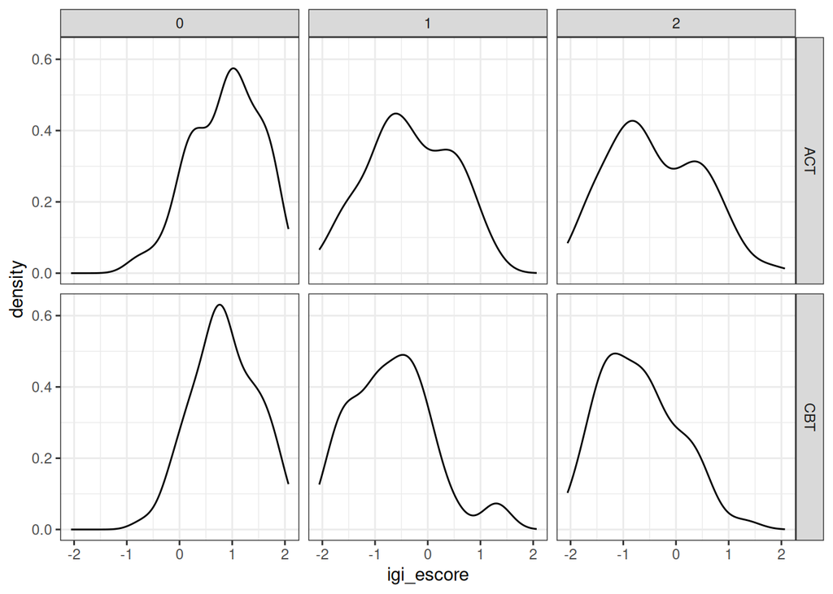

```r
data |>
  ggplot(aes( x = igi_escore)) +
  geom_density() +
  #facet_wrap(~ randomizacao) +
  facet_grid(randomizacao ~ redcap_event_name) +
  theme_bw()
```

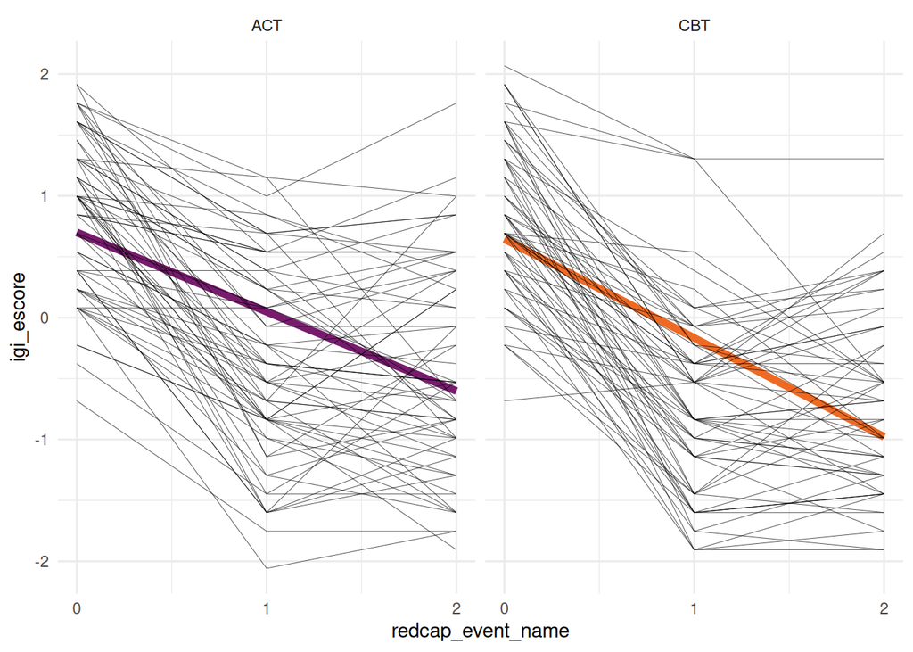

```r
data |>
  ggplot(aes(x = redcap_event_name, y  = igi_escore)) +
    stat_smooth(aes(color = randomizacao),
              method = "lm", formula = 'y ~ x',
              se = F, linewidth = 2) +
  geom_line(aes(group = record_id),
            linewidth = 1/6, alpha = 0.7) +
  scale_color_viridis_d(option = "B", begin = .33, end = .67) +
  facet_wrap(~ randomizacao) +
  scale_x_continuous(breaks = c(0, 1, 2 )) +
  theme_minimal() +
  theme(legend.position = "none")
```

# Choosing the model

```r
priors1 <- c(prior(normal(0, 5), class = b),
            prior(normal(0, 2), class = Intercept),
            prior(student_t(3, 0, 1), class = sigma),
            prior(gamma(1, .5), class = sd),
            prior(lkj_corr_cholesky(1), class = L))

stancode(data = df_complete,
         family = gaussian,
        igi_escore ~ 1 + redcap_event_name + randomizacao + redcap_event_name:randomizacao + (1 + redcap_event_name | record_id),
        prior = priors1)
```

```
## // generated with brms 2.21.0
## functions {
##  /* compute correlated group-level effects
##   * Args:
##   *   z: matrix of unscaled group-level effects
##   *   SD: vector of standard deviation parameters
##   *   L: cholesky factor correlation matrix
##   * Returns:
##   *   matrix of scaled group-level effects
##   */
##   matrix scale_r_cor(matrix z, vector SD, matrix L) {
##     // r is stored in another dimension order than z
##     return transpose(diag_pre_multiply(SD, L) * z);
##   }
## }
## data {
##   int<lower=1> N;  // total number of observations
##   vector[N] Y;  // response variable
##   int<lower=1> K;  // number of population-level effects
##   matrix[N, K] X;  // population-level design matrix
##   int<lower=1> Kc;  // number of population-level effects after centering
##   // data for group-level effects of ID 1
##   int<lower=1> N_1;  // number of grouping levels
##   int<lower=1> M_1;  // number of coefficients per level
##   array[N] int<lower=1> J_1;  // grouping indicator per observation
##   // group-level predictor values
##   vector[N] Z_1_1;
##   vector[N] Z_1_2;
##   vector[N] Z_1_3;
##   int<lower=1> NC_1;  // number of group-level correlations
##   int prior_only;  // should the likelihood be ignored?
## }
## transformed data {
##   matrix[N, Kc] Xc;  // centered version of X without an intercept
##   vector[Kc] means_X;  // column means of X before centering
##   for (i in 2:K) {
##     means_X[i - 1] = mean(X[, i]);
##     Xc[, i - 1] = X[, i] - means_X[i - 1];
##   }
## }
```

[output cut: 41 more lines]

```
##   target += std_normal_lpdf(to_vector(z_1));
## }
## generated quantities {
##   // actual population-level intercept
##   real b_Intercept = Intercept - dot_product(means_X, b);
##   // compute group-level correlations
##   corr_matrix[M_1] Cor_1 = multiply_lower_tri_self_transpose(L_1);
##   vector<lower=-1,upper=1>[NC_1] cor_1;
##   // extract upper diagonal of correlation matrix
##   for (k in 1:M_1) {
##     for (j in 1:(k - 1)) {
##       cor_1[choose(k - 1, 2) + j] = Cor_1[j, k];
##     }
##   }
## }
```

```r
fitPrior <-
  brm(data = df_complete,
      family = gaussian,
      igi_escore | mi() ~ 1 + redcap_event_name + randomizacao + redcap_event_name:randomizacao + (1 + redcap_event_name | record_id),
      cores = 16,
      seed = 133,
      prior = priors1,
      sample_prior = "only",
      control = list(adapt_delta = .85))
```

[output not shown]

## Prior predictive check

Based on the results from the prior predictive checks, the choice of priors seem reasonable. Although it can be observed a large variance of $y_{rep}$, the distribution is well centered around $y$. Therefore, the chosen model will be used in the final analysis.

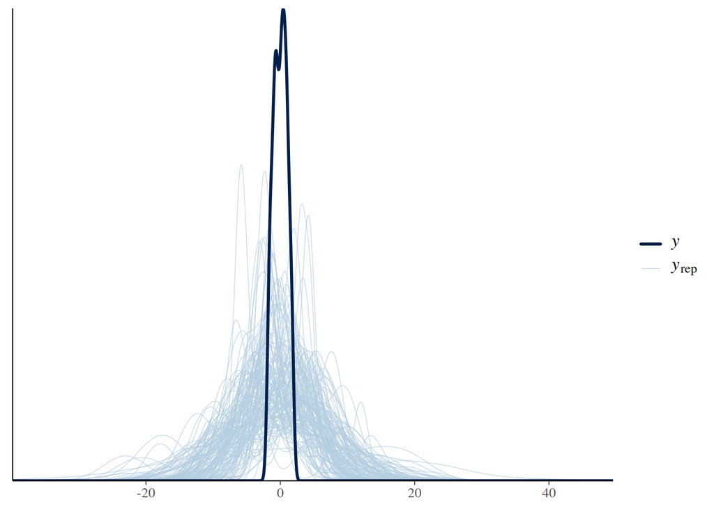

```r
pp_check(fitPrior, ndraws = 150)
```

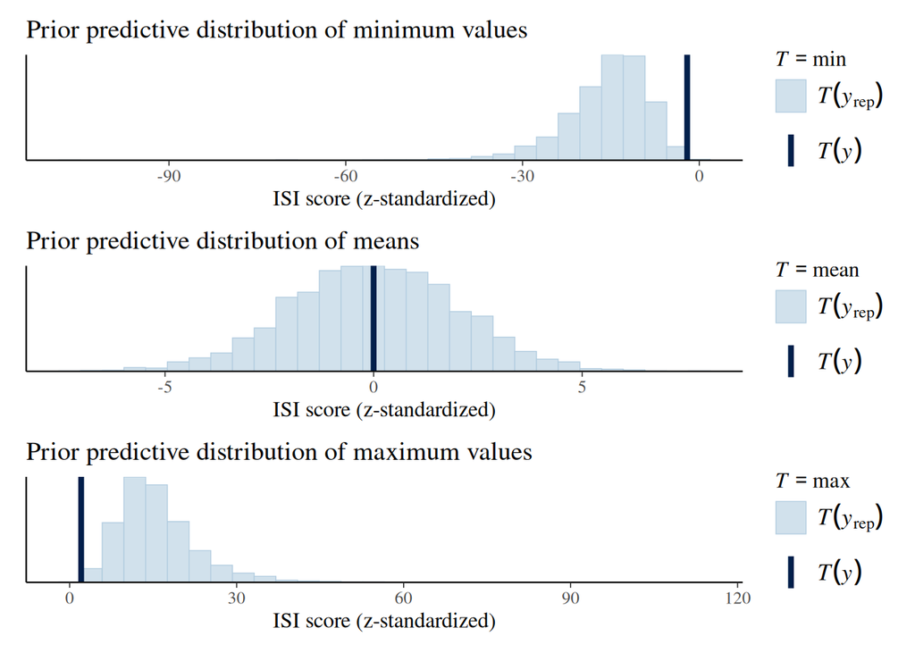

```r
p1 <- pp_check(fitPrior, type = 'stat', stat = 'min') +
  xlab('ISI score (z-standardized)') +
  ggtitle('Prior predictive distribution of minimum values')


p2 <- pp_check(fitPrior, type = 'stat', stat = 'mean') +
  xlab('ISI score (z-standardized)') +
  ggtitle('Prior predictive distribution of means')

p3 = pp_check(fitPrior, type = 'stat', stat = 'max') +
  xlab('ISI score (z-standardized)') +
  ggtitle('Prior predictive distribution of maximum values')

p123 = p1 + p2 + p3 + plot_layout(ncol = 1)
p123
```

# Fitting the model

```r
fit1 <-
  brm(data = df_complete,
      family = gaussian,
      igi_escore | mi() ~ 1 + redcap_event_name + randomizacao + redcap_event_name:randomizacao + (1 + redcap_event_name | record_id),
      cores = 16,
      seed = 133,
      prior = priors1,
      control = list(adapt_delta = .85))
```

[output not shown]

## Posterior predictive check

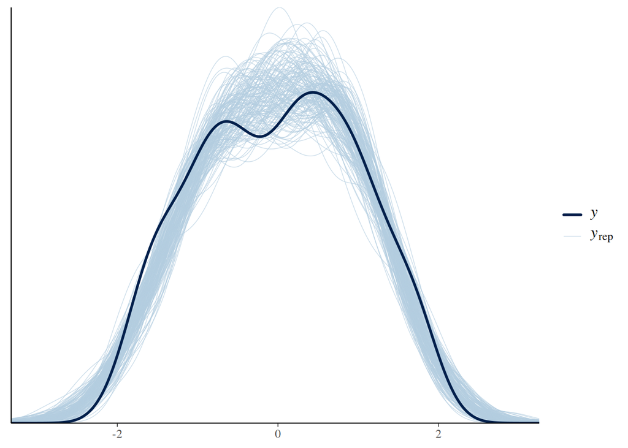

```r
brms::pp_check(fit1, ndraws = 150)
```

## Model diagnostics

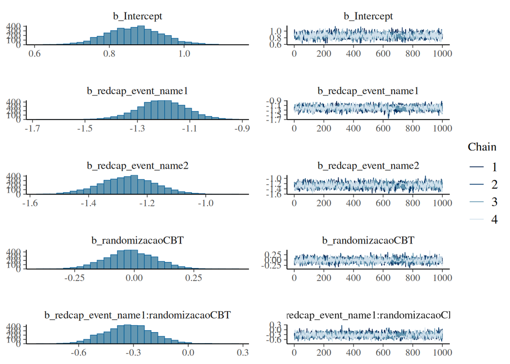

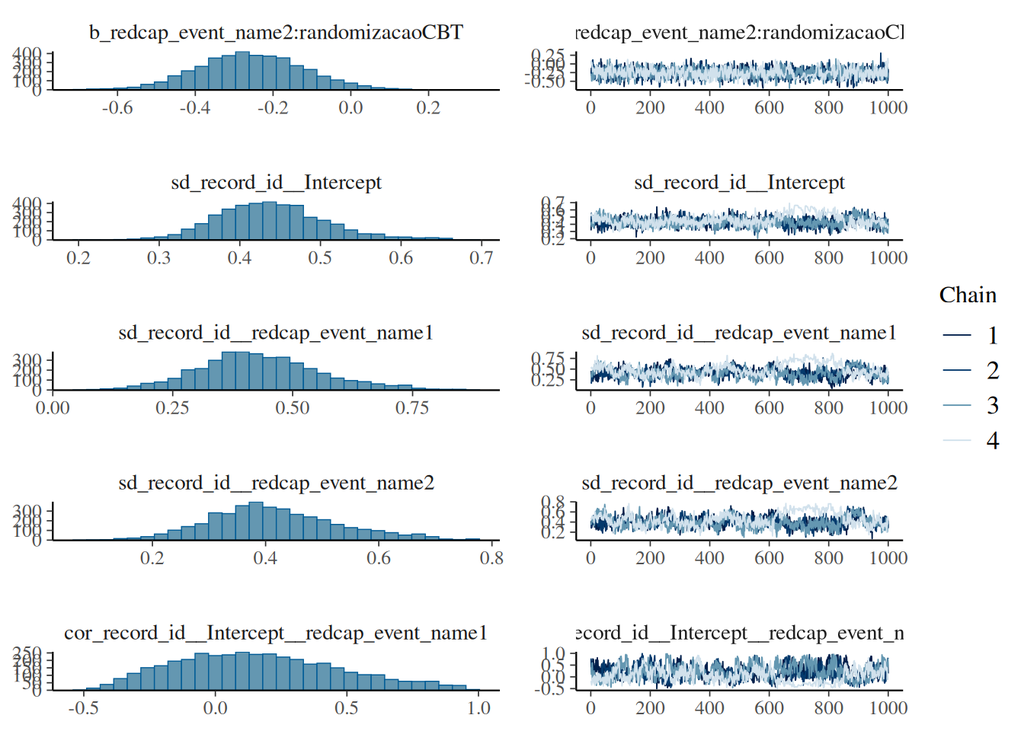

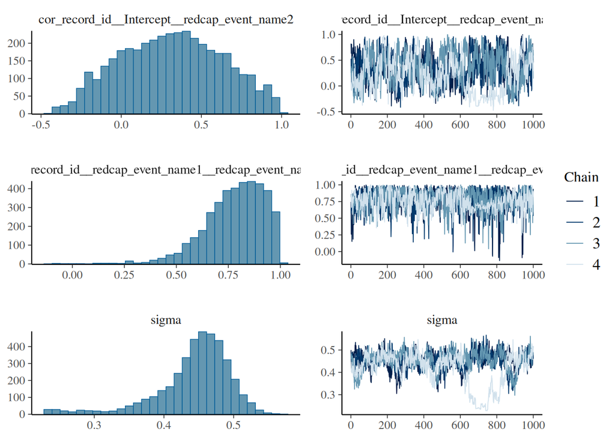

```r
plot(fit1)
```

## Model summary

```r
summary(fit1)
```

```
##  Family: gaussian
##   Links: mu = identity; sigma = identity
## Formula: igi_escore | mi() ~ 1 + redcap_event_name + randomizacao + redcap_event_name:randomizacao + (1 + redcap_event_name | record_id)
##    Data: df_complete (Number of observations: 456)
##   Draws: 4 chains, each with iter = 2000; warmup = 1000; thin = 1;
##          total post-warmup draws = 4000
##
## Multilevel Hyperparameters:
## ~record_id (Number of levels: 152)
##                                            Estimate Est.Error l-95% CI u-95% CI
## sd(Intercept)                                  0.44      0.07     0.32     0.59
## sd(redcap_event_name1)                         0.43      0.13     0.19     0.71
## sd(redcap_event_name2)                         0.42      0.11     0.22     0.67
## cor(Intercept,redcap_event_name1)              0.17      0.31    -0.35     0.82
## cor(Intercept,redcap_event_name2)              0.31      0.32    -0.26     0.91
## cor(redcap_event_name1,redcap_event_name2)     0.78      0.15     0.45     0.98
##                                            Rhat Bulk_ESS Tail_ESS
## sd(Intercept)                              1.04      115       63
## sd(redcap_event_name1)                     1.06       74       44
## sd(redcap_event_name2)                     1.05       87       54
## cor(Intercept,redcap_event_name1)          1.05       89      111
## cor(Intercept,redcap_event_name2)          1.05       87       80
## cor(redcap_event_name1,redcap_event_name2) 1.01      705     1446
##
## Regression Coefficients:
##                                    Estimate Est.Error l-95% CI u-95% CI Rhat
## Intercept                              0.87      0.07     0.72     1.01 1.00
## redcap_event_name1                    -1.21      0.09    -1.40    -1.02 1.00
## redcap_event_name2                    -1.27      0.09    -1.46    -1.09 1.00
## randomizacaoCBT                       -0.02      0.10    -0.22     0.19 1.00
## redcap_event_name1:randomizacaoCBT    -0.33      0.13    -0.58    -0.07 1.00
## redcap_event_name2:randomizacaoCBT    -0.26      0.14    -0.52     0.01 1.00
##                                    Bulk_ESS Tail_ESS
## Intercept                              1986     2983
## redcap_event_name1                     1698     2257
## redcap_event_name2                     1810     2559
## randomizacaoCBT                        2051     2731
## redcap_event_name1:randomizacaoCBT     1488     2702
## redcap_event_name2:randomizacaoCBT     1754     2437
##
## Further Distributional Parameters:
##       Estimate Est.Error l-95% CI u-95% CI Rhat Bulk_ESS Tail_ESS
## sigma     0.44      0.05     0.28     0.52 1.06       73       32
##
## Draws were sampled using sampling(NUTS). For each parameter, Bulk_ESS
## and Tail_ESS are effective sample size measures, and Rhat is the potential
## scale reduction factor on split chains (at convergence, Rhat = 1).
```

## Posterior density for the interactions

```r
# create a new df with the model estimates in the long format
model1tranformed <- ggmcmc::ggs(fit1)
```

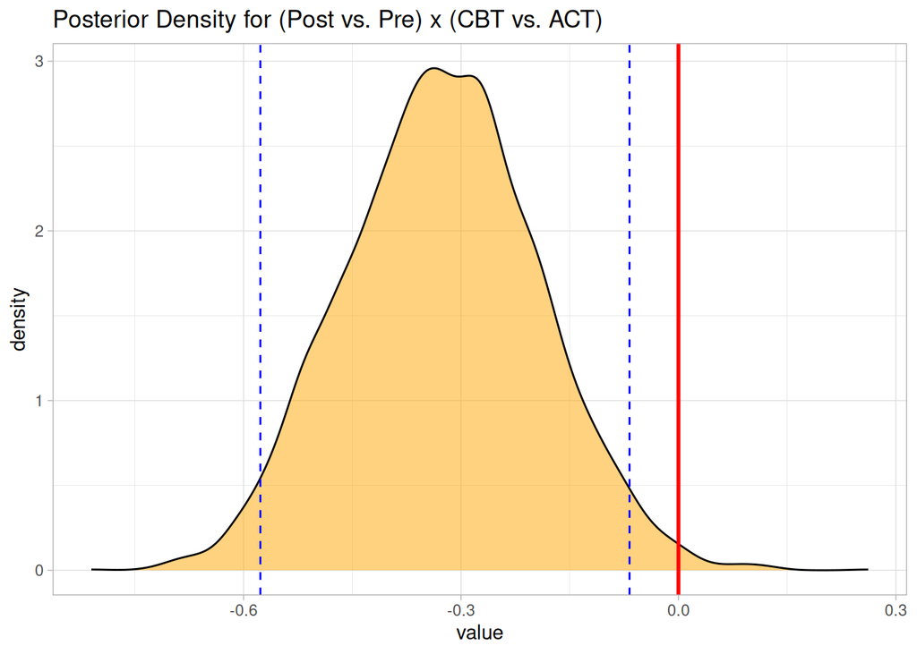

```r
ggplot(filter(model1tranformed, Parameter == "b_redcap_event_name1:randomizacaoCBT", Iteration > 1000), aes(x = value))+
  geom_density(fill = "orange", alpha = .5)+
  geom_vline(xintercept = 0, col = "red", size = 1)+
  #scale_x_continuous(name = "Value", limits = c(-.2, .6))+
  geom_vline(xintercept = summary(fit1)$fixed[5,3], col = "blue", linetype = 2)+
  geom_vline(xintercept = summary(fit1)$fixed[5,4], col = "blue", linetype = 2)+
  theme_light()+
  labs(title = "Posterior Density for (Post vs. Pre) x (CBT vs. ACT)")
```

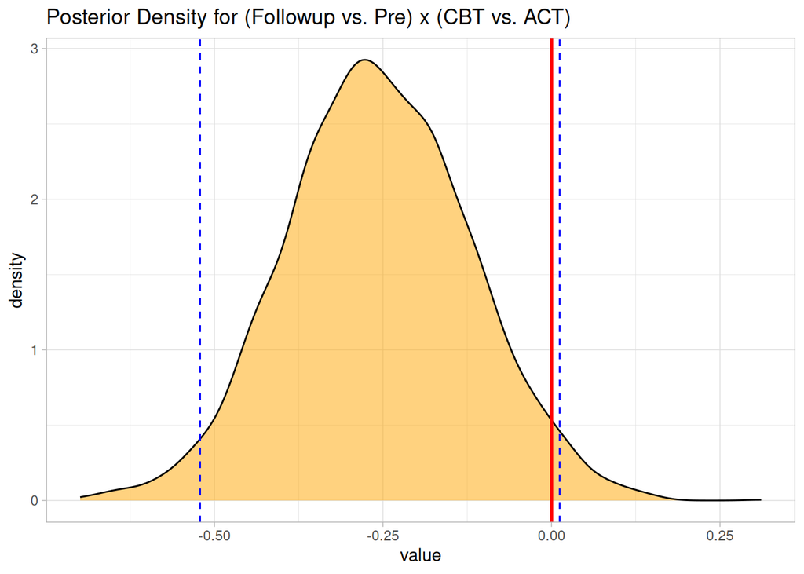

```r
ggplot(filter(model1tranformed, Parameter == "b_redcap_event_name2:randomizacaoCBT", Iteration > 1000), aes(x = value))+
  geom_density(fill = "orange", alpha = .5)+
  geom_vline(xintercept = 0, col = "red", size = 1)+
  #scale_x_continuous(name = "Value", limits = c(-.2, .6))+
  geom_vline(xintercept = summary(fit1)$fixed[6,3], col = "blue", linetype = 2)+
  geom_vline(xintercept = summary(fit1)$fixed[6,4], col = "blue", linetype = 2)+
  theme_light()+
  labs(title = "Posterior Density for (Followup vs. Pre) x (CBT vs. ACT)")
```